# Spike? What Spike?

“Randy Merritt, *Send me your numbers and I’ll tell you what they say.*”

March 2026

> *“COVID vaccine mandates are necessary because the protected need to be protected from the unprotected by forcing the unprotected to use the protection that didn’t protect the protected. Get it?”*

> —— [Steve Kirsch](https://stevekirsch.substack.com/)

This final paper closes the author’s involvement in the COVID-19 pandemic. Everything that can be said has been said. And few have documented the issues, on a global scale, surrounding the SARS-CoV-2 pandemic better than Ed Dowd in his book [Cause Unknown](https://www.skyhorsepublishing.com/9781648210730/cause-unknown/).

*The Cleveland Report* was a compendium of statistics pulled together to summarize various performance findings that had accrued through the end of 2021; the end of that calendar year where numerous reports were published revealing a serious “spike” in those statistics. The statistics were tracking the safety and effectiveness of various defense mechanisms applied during the COVID pandemic, including the new SARS-CoV-2 mRNA vaccine series.

This report is a short update offering a set of visualizations of statistics also drawn from the COVID pandemic. The graphs offered are from the [VAERS](https://vaers.hhs.gov/) datasets up through 2023. This report simply seeks to reinforce that calendar year 2021 was indeed **The Year of the Spike**.

*The Cleveland Report* report also included an exploration, by the author, of the [VAERS](https://vaers.hhs.gov/) datasets offered by the Federal health organizations. During the COVID-19 pandemic many were publishing their own findings and among those were a graph that claimed a spike in deaths recorded by VAERS in calendar year 2021. This graph was included in *The Cleveland Report* but without an adequate explanation of why it was there.

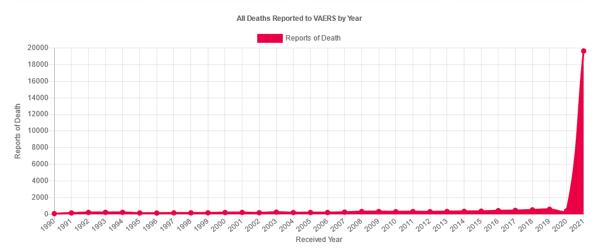

The originator of this graph was never determined. It simply appeared on the Web and the author was intrigued as to whether he could reproduce this graph using his own copy of the VAERS dataset.

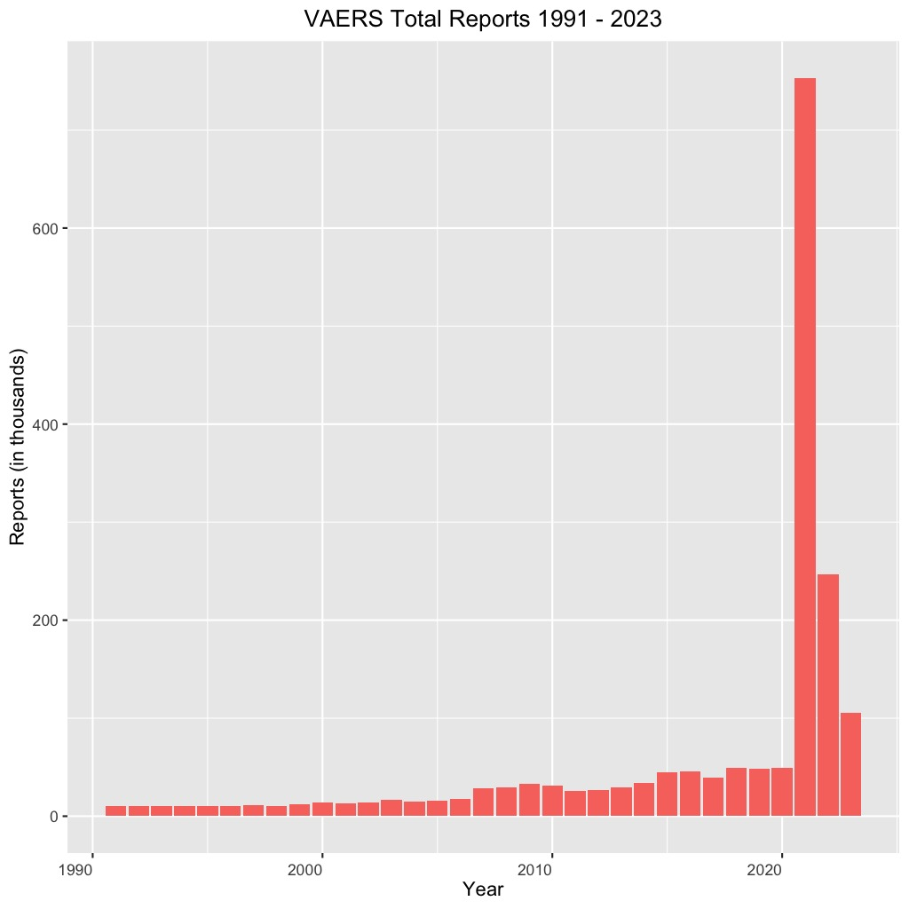

The FDA/CDC jointly managed Vaccine Adverse Effect Reporting system went live in November 1990. Unlike *The Cleveland Report* the graphs contained herein are solely the work of the author. The reader may wish to conduct their own research to find similar plots to corroborate these findings.

We begin by showing that as America has continually added vaccines to it’s vaccine inventory, each vaccine could be assumed to contribute some level to adverse effects. We clearly see a steady growth in adverse reports until 2021, where the reports submitted outright exploded. 2022 and even 2023 are clearly seen as significantly above the historical norm.

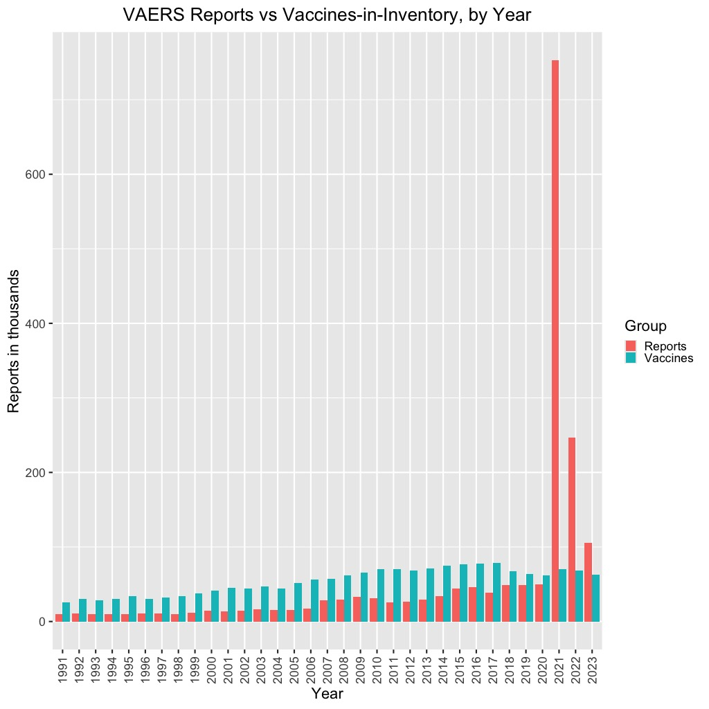

Here we present a clearer picture of the growth of vaccines in the American program with the level of reports submitted against those vaccines, per year. We note that starting around 2015 it appears the number of reports were at or over half the number of vaccines in inventory. Does this imply our vaccines were becoming more dangerous? As is clear from the graph, calendar years 2021, 2022, and even 2023 are markedly above the historical baseline.

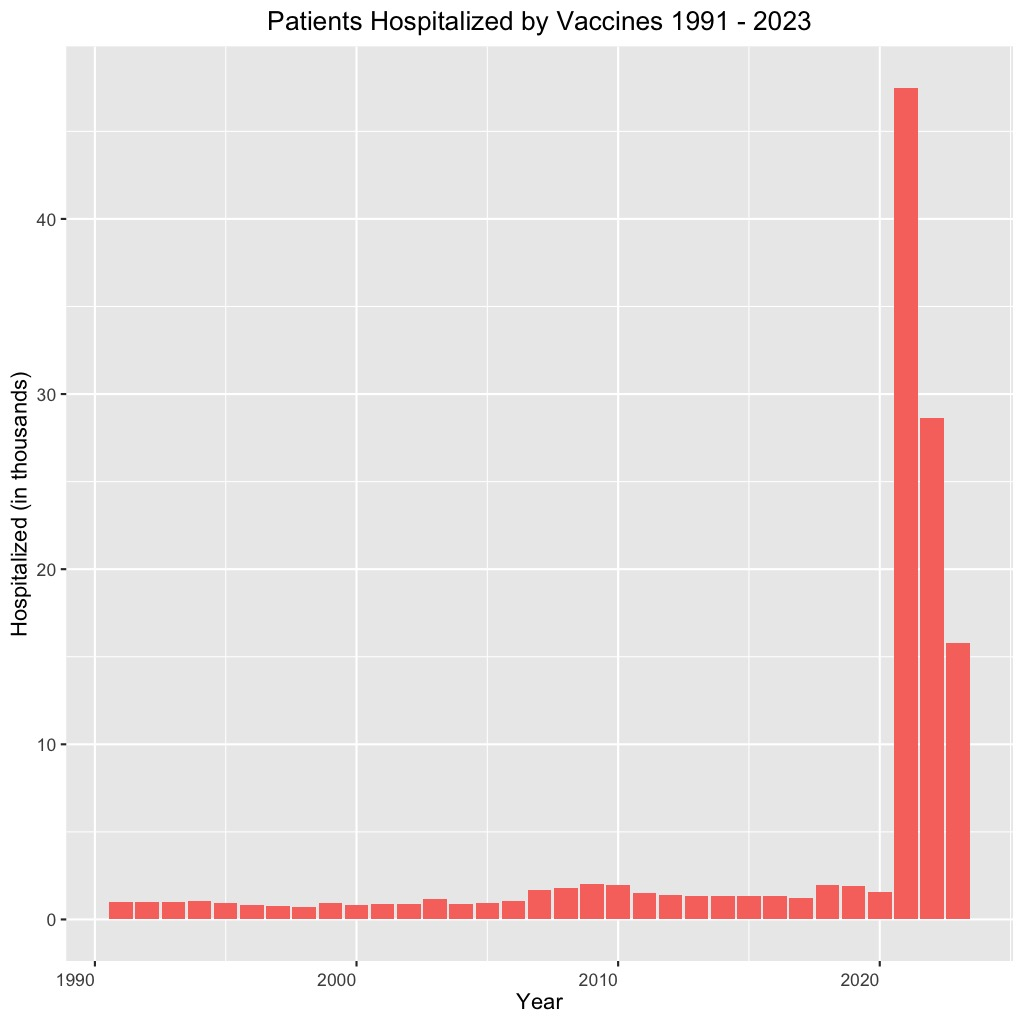

Now we settle into a series of graphs that show the history of severity in adverse reactions over time. Note the noticeable “bump” in 2007 through 2010.

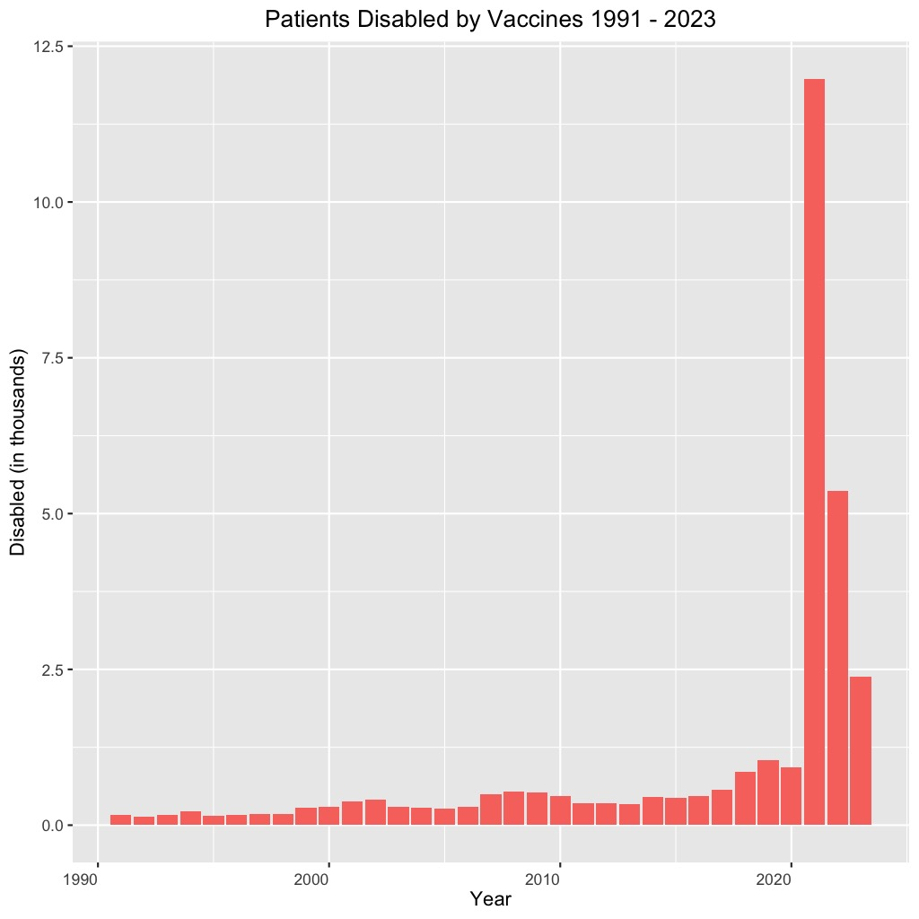

Here we’ve gone from a vaccine injection putting a patient into the hospital to resulting in a disability. Were these disabilities eventually corrected?

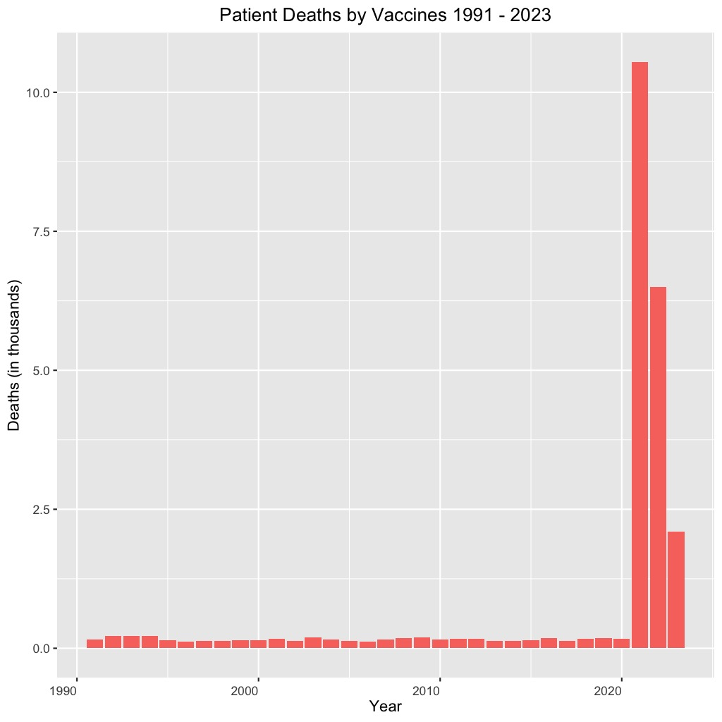

The ultimate adverse reaction – you didn’t survive the injection. Please note the scale of the y-axis. What happened to the Hippocratic Oath?

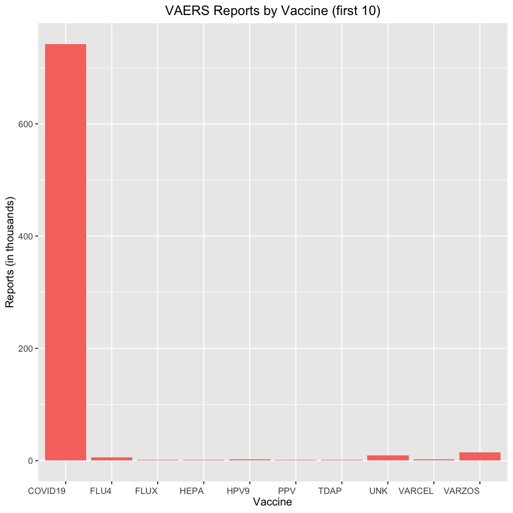

A relational join of the VAERS reports of 2021 with the vaccine table as of 2021 reveals the distribution of reports per vaccine. We order the report counts descending and show only the first 10 of those counts. The size in megabytes of the VAERS file that contains the adverse effects reports prior to 2021 grew to ~41 megabytes. The size of this file for 2021 alone measures 638 megabytes.

This size, along with the above graph, seals the conclusion that the “spike” of 2021 was caused by COVID-19 adverse reaction reports.

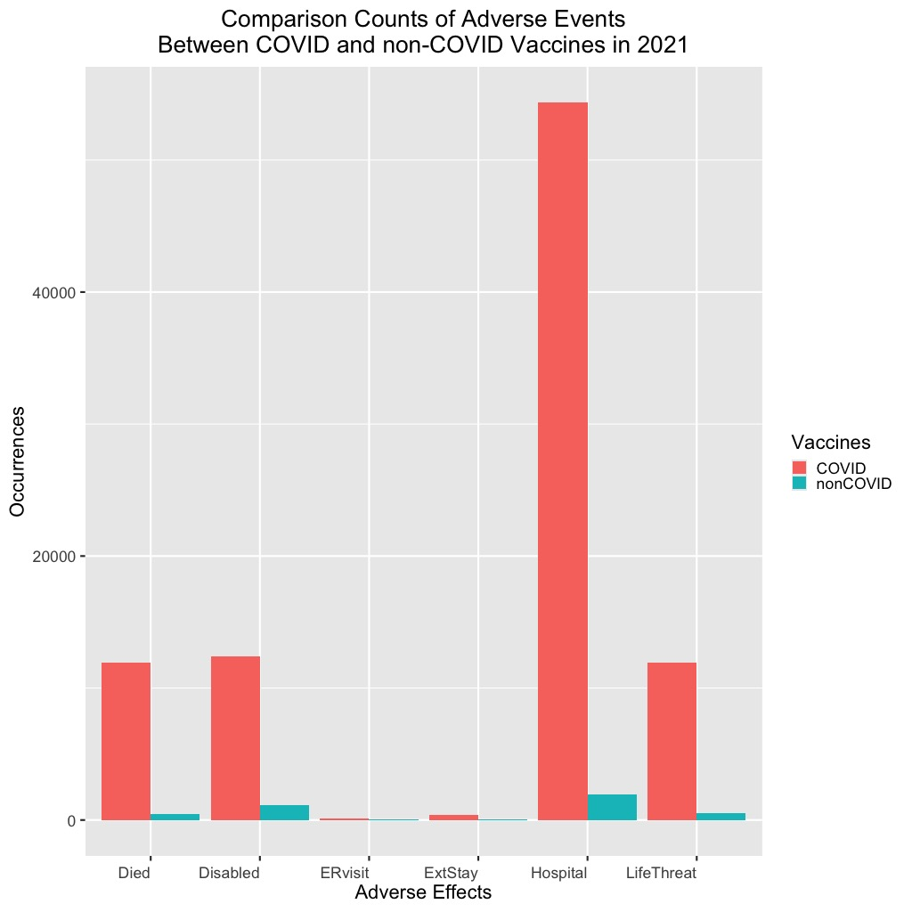

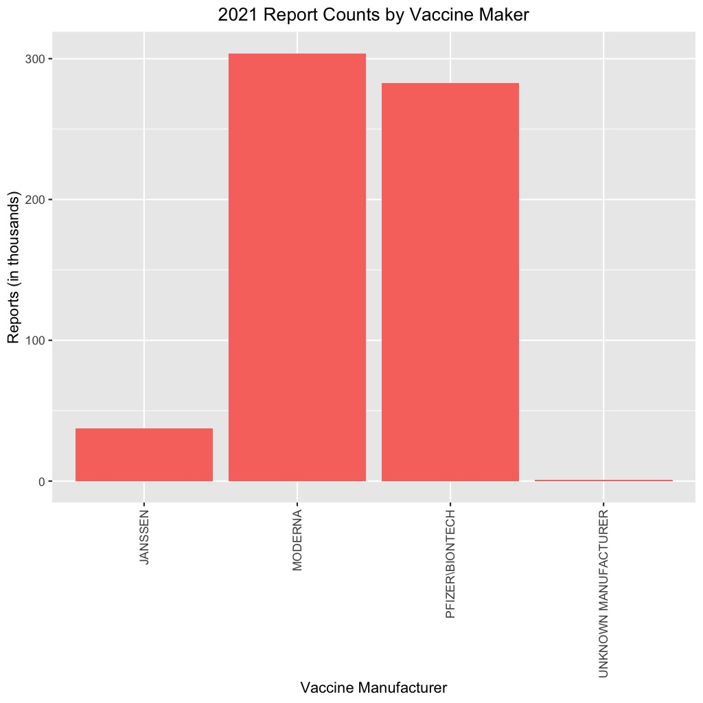

We end our visualizations of the 2021 COVID pandemic with a final graph relating adverse reactions by vaccine manufacturer.

But a caveat must be introduced for this graph - it’s not worth the paper it’s written on. Indeed, one can argue it shouldn’t be published at all. Why? Because, regrettably, VAERS does not include a best-estimate of total doses administered with each release of the data.

We do this in demographic studies all the time. We must scale demographic comparisons on a *per capita* basis, in order to do a true comparison. One cannot compare a demo statistic of Germany with the same of Switzerland, since Germany has more Germans than Switzerland has Swiss. Traditionally, the per-capita scale is per 100,000 of population.

This graph needs to scale it’s counts as a percentage of doses administered. For all we know, the Janssen variant may be twice as lethal than the Moderna variant as a percent of doses actually administered.

While not strictly a demonstration of a spike, this pie chart reveals an interesting statistic related to vaccine issues of 2021:

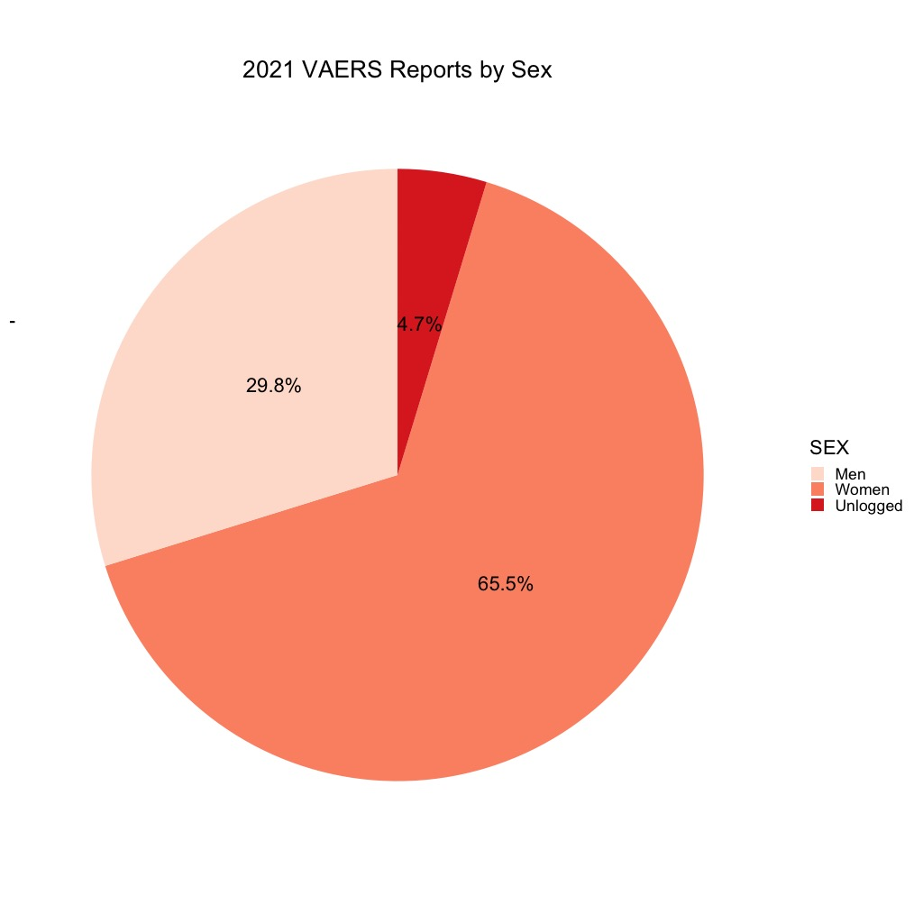

65.5% / 29.8% = ~2.2.

Does anyone know why?

### An Appendix

The release of the VAERS data used in the graphs for this paper was the final release of calendar year 2023.

```
## [1] "-rw-r--r--@ 1 randy  staff  502796340 Jan  5  2024 AllVAERSDataCSVS.zip"
```

```r
set.seed(314159)
library(tidyverse)
```